# Data Science Capstone — Milestone Report

Exploratory Analysis of the SwiftKey Text Corpora

Khaleel Khan

17 June 2026

## Executive summary

This is the milestone report for the Johns Hopkins **Data Science Capstone**. The end goal of the project is a Shiny web app that predicts the *next word* a user is likely to type, trained on a large collection of English text from blogs, news articles and Twitter.

This report covers the first stage of that work. In plain terms, it shows that I have:

1. **Downloaded and loaded** the three English text files successfully.
2. Produced **basic summary statistics** for each file (size, lines, words).
3. Explored the data with **plots** of line lengths and the most common words and phrases.
4. Laid out a **plan** for the prediction model and the app.

No data-science background is needed to read it — the technical code is hidden by default (use the **Code** buttons on the right to reveal any of it).

## The data

The data comes from the course’s [SwiftKey dataset](https://d396qusza40orc.cloudfront.net/dsscapstone/dataset/Coursera-SwiftKey.zip). It contains text in four languages; I use only the three English files:

- `en_US.blogs.txt` — text from blog posts
- `en_US.news.txt` — text from news articles
- `en_US.twitter.txt` — tweets

```r
# Run once to fetch and unzip the data (not re-run on every knit).
url <- "https://d396qusza40orc.cloudfront.net/dsscapstone/dataset/Coursera-SwiftKey.zip"
dir.create("data/raw", recursive = TRUE, showWarnings = FALSE)
download.file(url, "data/raw/Coursera-SwiftKey.zip", mode = "wb")
unzip("data/raw/Coursera-SwiftKey.zip", exdir = "data/raw")
```

```r
data_dir <- "data/raw/final/en_US"
files <- c(Blogs = "en_US.blogs.txt",
           News  = "en_US.news.txt",
           Twitter = "en_US.twitter.txt")
paths <- file.path(data_dir, files)

# Read a file and return it as a clean (valid-UTF-8) character vector of lines.
read_clean <- function(path) {
  con <- file(path, open = "r", encoding = "UTF-8")
  txt <- readLines(con, skipNul = TRUE, warn = FALSE)
  close(con)
  iconv(txt, from = "UTF-8", to = "UTF-8", sub = "")
}

corpora <- lapply(paths, read_clean)
names(corpora) <- names(files)
```

## Basic summary statistics

For each file I record its size on disk, the number of lines, the total number of words, and the length of the longest single line.

```r
summary_tbl <- tibble(
  File                   = names(files),
  `Size (MB)`            = round(file.info(paths)$size / 2^20, 1),
  Lines                  = map_int(corpora, length),
  Words                  = map_dbl(corpora, ~ sum(str_count(.x, "\\S+"))),
  `Mean words / line`    = round(Words / Lines, 1),
  `Longest line (chars)` = map_int(corpora, ~ max(nchar(.x)))
)

knitr::kable(
  summary_tbl,
  format.args = list(big.mark = ","),
  caption = "Table 1. Summary of the three English corpora."
)
```

Table 1. Summary of the three English corpora.

| File | Size (MB) | Lines | Words | Mean words / line | Longest line (chars) |
| --- | --- | --- | --- | --- | --- |
| Blogs | 200.4 | 899,288 | 37,334,131 | 41.5 | 40,833 |
| News | 196.3 | 1,010,206 | 34,371,031 | 34.0 | 11,384 |
| Twitter | 159.4 | 2,360,148 | 30,373,583 | 12.9 | 140 |

All three files are large — together hundreds of megabytes and millions of lines. Twitter has by far the most lines (each tweet is short), while blogs and news have fewer but much longer lines.

## Sampling

Because the files are so large, training and exploring on all of them at once is slow and memory-hungry. Following standard practice, I take a random **2% sample** of lines from each file and combine them. This is more than enough to reveal the structure of the language while keeping the analysis fast and reproducible.

```r
samp <- imap_dfr(corpora, function(lines, src) {
  keep <- rbinom(length(lines), size = 1, prob = 0.02) == 1
  tibble(source = src, text = lines[keep])
})

# Free the full corpora from memory now that we have the sample.
rm(corpora); invisible(gc())

sample_size <- nrow(samp)
```

The combined sample has **85,058** lines of text.

## Words per line

A first useful view is how long the lines are in each source. Twitter lines are capped short (tweets were 140 characters at the time), blogs and news run longer.

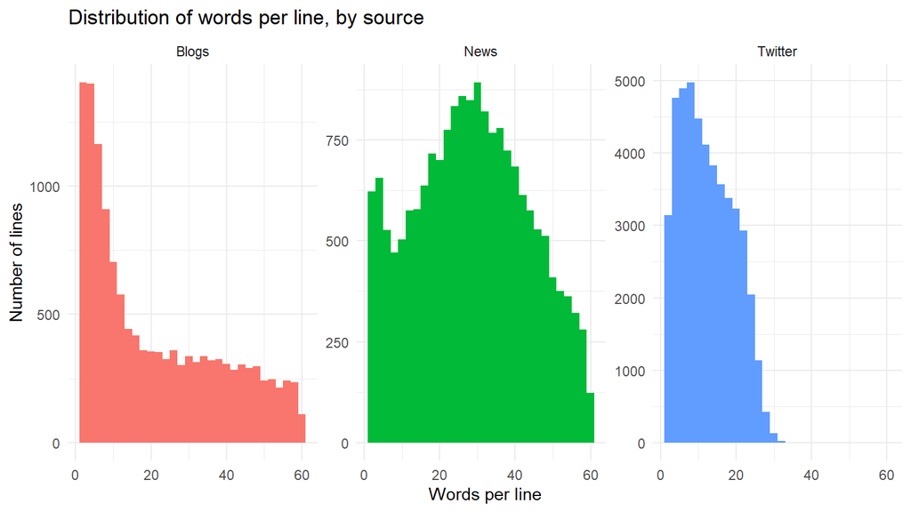

```r
samp %>%
  mutate(words = str_count(text, "\\S+")) %>%
  filter(words <= 60) %>%
  ggplot(aes(words, fill = source)) +
  geom_histogram(binwidth = 2, show.legend = FALSE) +
  facet_wrap(~ source, scales = "free_y") +
  labs(title = "Distribution of words per line, by source",
       x = "Words per line", y = "Number of lines") +
  theme_minimal()
```

## Most common words and phrases

I tokenise the sampled text into single words (**unigrams**), word pairs (**bigrams**) and word triples (**trigrams**), dropping tokens that contain digits. N-grams are the foundation of the prediction model: to guess the next word, the model looks at the last one or two words typed and asks “what most often comes next?”

```r
unigrams <- samp %>%
  unnest_tokens(word, text) %>%
  filter(!str_detect(word, "[0-9]")) %>%
  count(word, sort = TRUE)

bigrams <- samp %>%
  unnest_tokens(bigram, text, token = "ngrams", n = 2) %>%
  filter(!is.na(bigram), !str_detect(bigram, "[0-9]")) %>%
  count(bigram, sort = TRUE)

trigrams <- samp %>%
  unnest_tokens(trigram, text, token = "ngrams", n = 3) %>%
  filter(!is.na(trigram), !str_detect(trigram, "[0-9]")) %>%
  count(trigram, sort = TRUE)
```

```r
top_plot <- function(df, col, title, fill) {
  df %>%
    slice_max(n, n = 15) %>%
    mutate(term = reorder(.data[[col]], n)) %>%
    ggplot(aes(n, term)) +
    geom_col(fill = fill) +
    scale_x_continuous(labels = comma) +
    labs(title = title, x = "Frequency", y = NULL) +
    theme_minimal()
}
```

### Top single words

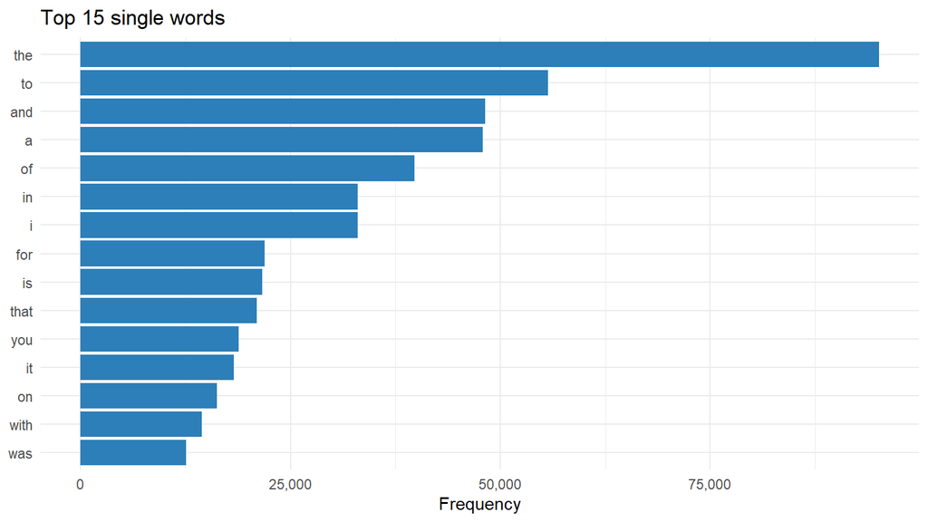

```r
top_plot(unigrams, "word", "Top 15 single words", "#2c7fb8")
```

As expected, the list is dominated by common English function words (“the”, “to”, “and”, …). These carry little meaning on their own but are essential for predicting fluent text, so I keep them in.

### Top word pairs (bigrams)

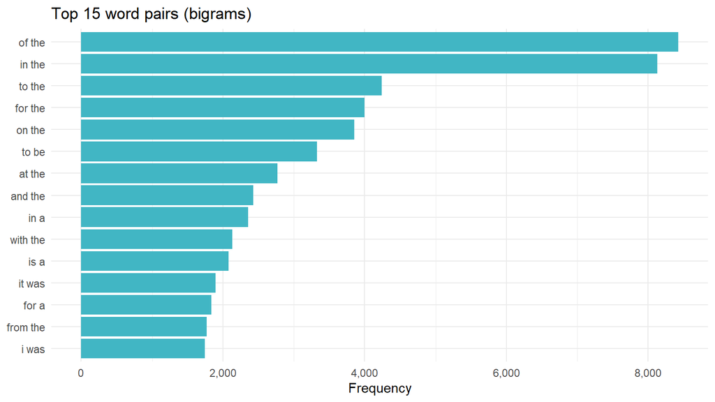

```r
top_plot(bigrams, "bigram", "Top 15 word pairs (bigrams)", "#41b6c4")
```

### Top word triples (trigrams)

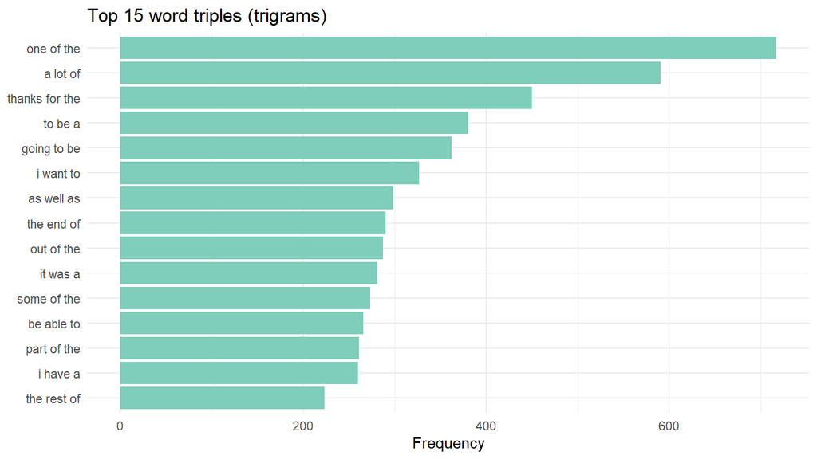

```r
top_plot(trigrams, "trigram", "Top 15 word triples (trigrams)", "#7fcdbb")
```

## An interesting finding: word coverage

A small number of words accounts for most of the text. The chart below shows the **cumulative coverage**: how much of all word usage is explained as we add more of the most frequent unique words.

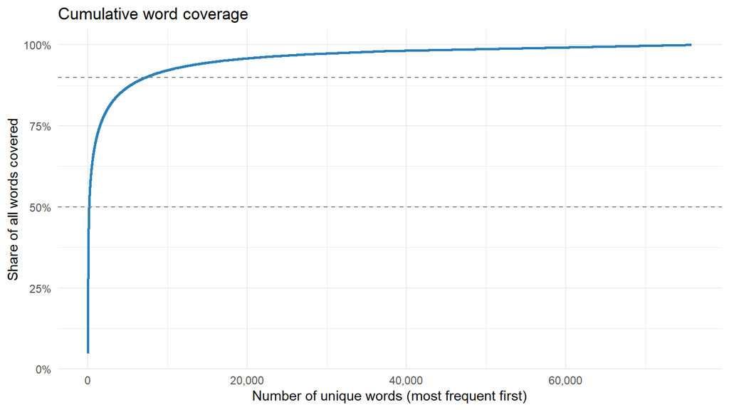

```r
coverage <- unigrams %>%
  mutate(rank = row_number(),
         cum_cov = cumsum(n) / sum(n))

n50 <- coverage %>% filter(cum_cov >= 0.50) %>% slice(1) %>% pull(rank)
n90 <- coverage %>% filter(cum_cov >= 0.90) %>% slice(1) %>% pull(rank)
total_unique <- nrow(unigrams)

ggplot(coverage, aes(rank, cum_cov)) +
  geom_line(colour = "#2c7fb8", linewidth = 1) +
  geom_hline(yintercept = c(0.5, 0.9), linetype = "dashed", colour = "grey50") +
  scale_y_continuous(labels = percent) +
  scale_x_continuous(labels = comma) +
  labs(title = "Cumulative word coverage",
       x = "Number of unique words (most frequent first)",
       y = "Share of all words covered") +
  theme_minimal()
```

Only about **144** unique words are needed to cover **50%** of all word usage, and about **7,284** to cover **90%** — out of roughly **75,798** unique words in the sample. This matters a lot for the app: a relatively small dictionary can handle the vast majority of what users type, which keeps the model small and fast.

## Plan for the prediction model and Shiny app

Based on this exploration, my plan is:

1. **Build n-gram frequency tables** (unigram → quadgram) from a larger sample of the cleaned corpus, keeping only n-grams above a small frequency threshold to control size.
2. **Predict with a back-off model.** Given the last few words typed, look up the matching trigram/quadgram; if none is found, “back off” to the bigram, then to the most common unigrams. (Stupid back-off is fast and works well for this task.)
3. **Optimise for size and speed** so it can run on the free Shiny hosting tier — prune rare n-grams and store the tables efficiently.
4. **Build the Shiny app**: a text box where the user types, and the app shows the top few predicted next words, updating as they type.
5. **Validate** accuracy on a held-out sample and present the result in a short slide deck.

Feedback I’d welcome: whether 2% sampling is enough, and the right trade-off between model size and prediction accuracy for the hosted app.